# Creating images with R

with a little bit of magick

Eliya Williams

```css
@import url('https://fonts.googleapis.com/css2?family=Quicksand:wght@400;700&display=swap');

h1, h2 {
  font-family: 'Quicksand', sans-serif;
  font-weight: 700;
  color: #000000;
  text-align: center;
  background: #C1D9B1;
  border-radius: 15px 35px;
  padding: 20px;
}

h3, h4 {
  font-family: 'Quicksand', sans-serif;
  font-weight: 700;
  color: #000000;
  text-align: center;
}

.Paragraphs {
  font-family: 'Quicksand', sans-serif;
  font-size: 17px;
  font-weight: 400;
  background: #F1F1F1;
  border-radius: 10px;
  padding: 20px;
}
```

## My meme

My meme conveys my personal experience of choosing to study Statistics and my expectation versus reality of what that would look like. In my ignorance, I expected Statistics to involve making pretty graphs and drawing conclusions from them. However, in my second year of Statistics, I soon found myself having to learn R-coding and I felt very surprised and a little bit scared of the challenge. I fondly reflect on this experience because I can see how much I have learned by taking the challenge and doing my best. So I thought creating a meme would be a creative opportunity to share this experience light-heartedly. I have not seen or heard anything similar to my expectations or feelings toward studying Statistics. Also, because my meme is based on personal experience, I think this showcases the newness and originality of my meme.

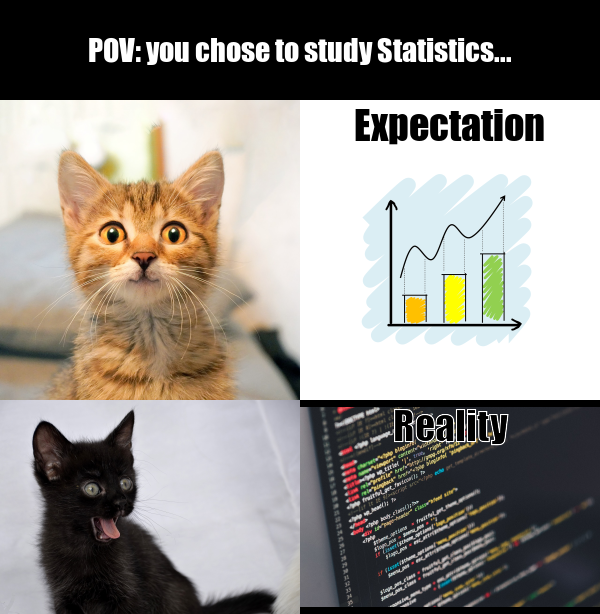

```r
library(magick)

# Reading in the happy cat image and scaling it to 300 pixels

happy_cat <- image_read("Images/Happy_cat.jpg") %>%
  image_scale(300)

# Reading in the surprised cat image and scaling it to 300 pixels

surprised_cat <- image_read("Images/Surprised_cat.jpg") %>%
  image_scale(300)

# Reading in the graph image, scaling it to 300 pixels, adding a border, and then adding text

graph_image <- image_read("Images/Graph.png") %>%
  image_scale(300) %>%
  image_border("#FFFFFF", "0x37") %>%
  image_annotate(text = "Expectation",
                 col = "#000000",
                 size = 40,
                 font = "Impact",
                 gravity = "north")

# Reading in the code image, scaling it to 300 pixels, adding a border, and then adding text

code_image <- image_read("Images/Code.jpg") %>%
  image_scale(300) %>%
  image_border("#000000", "0x7") %>%
  image_annotate(text = "Reality",
                 col = "#000000",
                 size = 40,
                 font = "Impact",
                 strokecolor = "#FFFFFF",
                 gravity = "north")

# Creating a blank image and then adding text, to create the first row

row_one <- image_blank(width = 600,
                       height = 100,
                       col = "#000000") %>%
  image_annotate(text = "POV: you chose to study Statistics...",
                 col = "#FFFFFF",
                 size = 30,
                 font = "Impact",
                 gravity = "center")

# Creating a vector with the graph and happy cat images and then combining them to create the second row

row_two <- c(happy_cat, graph_image) %>%
  image_append()

# Creating a vector with the code and surprised cat images and then combining them to create the third row

row_three <- c(surprised_cat, code_image) %>%
  image_append()

# Creating a vector with all three rows and then combining them by stacking the images on top of each other to create the final meme

final_meme <- c(row_one, row_two, row_three) %>%
  image_append(stack = T)

# Saving the final meme to a .png file

image_write(final_meme, "my_meme.png")
```

## My animated GIF

My animated GIF is an encouraging reminder that today is a new day. When I get overwhelmed, I often find it easy to be taken over by anxiety. I like to remember that each new day offers new opportunities. Just as the sun presents a new day, I wanted this animated GIF to remind others, and myself, to take each day as it comes. I find this encouraging and hope to share it with others. Although this animated GIF is nice and simple, it conveys an important message, easily forgotten in a society that is always moving forward. I think this is how my animated GIF is new and original.

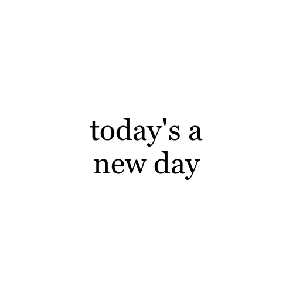

```r
library(magick)

# Reading in the sun image and scaling it to 500 pixels

sun_image <- image_read("Images/Sun_illustration.png") %>%
  image_scale(500)

# For frame 1: Creating a blank image that is 500x500 pixels and then adding text

frame_1 <- image_blank(width = 500,
                       height = 500,
                       col = "#FFFFFF") %>%
  image_annotate("today's a\nnew day",
                 gravity = "center",
                 size = 50,
                 font = "Georgia")

# For frames 2 to 4: Cropping the sun image, by a quarter each time, of it's original size, adding more white space and a background (so that the GIF stays the same size in each frame) and then adding text

frame_2 <- sun_image %>%
  image_crop("500x125") %>%
  image_extent("500x500",
               gravity = "south") %>%
  image_background("#FFFFFF") %>%
  image_annotate("today's a\nnew day",
                 gravity = "center",
                 size = 50,
                 font = "Georgia")

frame_3 <- sun_image %>%
  image_crop("500x250") %>%
  image_extent("500x500",
               gravity = "south") %>%
  image_background("#FFFFFF") %>%
  image_annotate("today's a\nnew day",
                 gravity = "center",
                 size = 50,
                 font = "Georgia")

frame_4 <- sun_image %>%
  image_crop("500x375") %>%
  image_extent("500x500",
               gravity = "south") %>%
  image_background("#FFFFFF") %>%
  image_annotate("today's a\nnew day",
                 gravity = "center",
                 size = 50,
                 font = "Georgia")

# For frame 5: Centering the sun image and adding a white background (so that the GIF stays the same size in each frame), and then adding text

frame_5 <- sun_image %>%
  image_extent("500x500",
               gravity = "center") %>%
  image_background("#FFFFFF") %>%
  image_annotate("today's a\nnew day",
                 gravity = "center",
                 size = 50,
                 font = "Georgia")

# For frames 6 to 8: Rotating the sun image by 90 degrees each time, centering the sun image and adding a white background (so that the GIF stays the same size in each frame), and then adding text

frame_6 <- sun_image %>%
  image_rotate(90) %>%
  image_extent("500x500",
               gravity = "center") %>%
  image_background("#FFFFFF") %>%
  image_annotate("today's a\nnew day",
                 gravity = "center",
                 size = 50,
                 font = "Georgia")

frame_7 <- sun_image %>%
  image_rotate(180) %>%
  image_extent("500x500",
               gravity = "center") %>%
  image_background("#FFFFFF") %>%
  image_annotate("today's a\nnew day",
                 gravity = "center",
                 size = 50,
                 font = "Georgia")

frame_8 <- sun_image %>%
  image_rotate(270) %>%
  image_extent("500x500",
               gravity = "center") %>%
  image_background("#FFFFFF") %>%
  image_annotate("today's a\nnew day",
                 gravity = "center",
                 size = 50,
                 font = "Georgia")

# Creating a vector with frames 1 to 8 (in the order of appearing in the GIF) and then animating these frames to create the final animated GIF

final_animation <- c(frame_1, frame_2, frame_3, frame_4, frame_5, frame_6, frame_7, frame_8, frame_5) %>%
  image_animate(fps = 2)

# Saving the final animation to a .gif file

image_write(final_animation, "my_animation.gif")
```